# Segmentation de la clientèle à l'aide du clustering by Saad TAZROUTE

Un mini-projet réalisé dans le cadre de ma auto-formation à l'Ecole Centrale Casablanca.

```python
%matplotlib inline
import pandas as pd
import sklearn
import matplotlib.pyplot as plt
import seaborn as sns
import os
# Setup Seaborn
sns.set_style("white")
sns.set_context("talk")

path='ton/dossier/de/travail'
os.chdir(path)
```

## Data

L'ensemble de données contient des informations sur les lettres d'information/les campagnes de marketing par courrier électronique (offres envoyées aux clients par courrier électronique) et des données sur les transactions effectuées par les clients. Les données transactionnelles indiquent l'offre à laquelle les clients ont répondu et ce qu'ils ont fini par acheter. Les données sont présentées sous la forme d'un classeur Excel contenant deux feuilles de calcul. Chaque feuille de calcul contient un ensemble de données différent.

```python
df_offers = pd.read_excel("./WineKMC.xlsx", sheet_name=0)
df_offers.columns = ["offer_id", "campaign", "varietal", "min_qty", "discount", "origin", "past_peak"]
df_offers.head()
```

|  | offer_id | campaign | varietal | min_qty | discount | origin | past_peak |
| --- | --- | --- | --- | --- | --- | --- | --- |
| 0 | 1 | January | Malbec | 72 | 56 | France | False |
| 1 | 2 | January | Pinot Noir | 72 | 17 | France | False |
| 2 | 3 | February | Espumante | 144 | 32 | Oregon | True |
| 3 | 4 | February | Champagne | 72 | 48 | France | True |
| 4 | 5 | February | Cabernet Sauvignon | 144 | 44 | New Zealand | True |

Nous voyons que le premier ensemble de données contient des informations sur chaque offre, comme le mois où elle est en vigueur et plusieurs attributs sur le vin auquel l'offre se réfère : le cépage, la quantité minimale, la remise, le pays d'origine et le fait qu'elle ait ou non dépassé le pic. Le deuxième ensemble de données de la deuxième feuille de calcul contient des données transactionnelles, c'est-à-dire l'offre à laquelle chaque client a répondu.

```python
df_transactions = pd.read_excel("./WineKMC.xlsx", sheet_name=1)
df_transactions.columns = ["customer_name", "offer_id"]
df_transactions['n'] = 1
df_transactions.head()
```

|  | customer_name | offer_id | n |
| --- | --- | --- | --- |
| 0 | Smith | 2 | 1 |
| 1 | Smith | 24 | 1 |
| 2 | Johnson | 17 | 1 |
| 3 | Johnson | 24 | 1 |
| 4 | Johnson | 26 | 1 |

## Data wrangling

Nous essayons d'en savoir plus sur le comportement de nos clients, afin de pouvoir utiliser leur comportement (qu'ils aient ou non acheté quelque chose sur la base d'une offre) comme un moyen de regrouper les clients aux vues similaires. Nous pouvons ensuite étudier ces groupes pour rechercher des modèles et des tendances qui peuvent nous aider à formuler de futures offres.

La première chose dont nous avons besoin est un moyen de comparer les clients. Pour ce faire, nous allons créer une matrice qui contient chaque client et un indicateur 0/1 pour savoir s'ils ont répondu ou non à une offre donnée.

On Crée un Dataframe où chaque ligne comporte les colonnes suivantes (On utilise les fonctions de pandas [`merge`] and [`pivot_table`] pour ceci):

  On traite également toute valeur bizarre comme "NaN". Lisez la documentation pour développer votre solution.

```python
# Merge offer data to each transaction
df_merge = df_transactions.merge(df_offers, left_on='offer_id', right_on='offer_id', how='left')
df_merge.head()
```

|  | customer_name | offer_id | n | campaign | varietal | min_qty | discount | origin | past_peak |
| --- | --- | --- | --- | --- | --- | --- | --- | --- | --- |
| 0 | Smith | 2 | 1 | January | Pinot Noir | 72 | 17 | France | False |
| 1 | Smith | 24 | 1 | September | Pinot Noir | 6 | 34 | Italy | False |
| 2 | Johnson | 17 | 1 | July | Pinot Noir | 12 | 47 | Germany | False |
| 3 | Johnson | 24 | 1 | September | Pinot Noir | 6 | 34 | Italy | False |
| 4 | Johnson | 26 | 1 | October | Pinot Noir | 144 | 83 | Australia | False |

```python
# Display customers in rows and let each column represent an offer
customers = pd.pivot_table(df_merge, values='n', index='customer_name', columns='offer_id')
customers = customers.fillna(0).reset_index()
customers.head()
```

| offer_id | customer_name | 1 | 2 | 3 | 4 | 5 | 6 | 7 | 8 | 9 | ... | 23 | 24 | 25 | 26 | 27 | 28 | 29 | 30 | 31 | 32 |
| --- | --- | --- | --- | --- | --- | --- | --- | --- | --- | --- | --- | --- | --- | --- | --- | --- | --- | --- | --- | --- | --- |
| 0 | Adams | 0.0 | 0.0 | 0.0 | 0.0 | 0.0 | 0.0 | 0.0 | 0.0 | 0.0 | ... | 0.0 | 0.0 | 0.0 | 0.0 | 0.0 | 0.0 | 1.0 | 1.0 | 0.0 | 0.0 |
| 1 | Allen | 0.0 | 0.0 | 0.0 | 0.0 | 0.0 | 0.0 | 0.0 | 0.0 | 1.0 | ... | 0.0 | 0.0 | 0.0 | 0.0 | 1.0 | 0.0 | 0.0 | 0.0 | 0.0 | 0.0 |
| 2 | Anderson | 0.0 | 0.0 | 0.0 | 0.0 | 0.0 | 0.0 | 0.0 | 0.0 | 0.0 | ... | 0.0 | 1.0 | 0.0 | 1.0 | 0.0 | 0.0 | 0.0 | 0.0 | 0.0 | 0.0 |
| 3 | Bailey | 0.0 | 0.0 | 0.0 | 0.0 | 0.0 | 0.0 | 1.0 | 0.0 | 0.0 | ... | 0.0 | 0.0 | 0.0 | 0.0 | 0.0 | 0.0 | 0.0 | 1.0 | 0.0 | 0.0 |
| 4 | Baker | 0.0 | 0.0 | 0.0 | 0.0 | 0.0 | 0.0 | 1.0 | 0.0 | 0.0 | ... | 0.0 | 0.0 | 0.0 | 0.0 | 0.0 | 0.0 | 0.0 | 0.0 | 1.0 | 0.0 |

5 rows × 33 columns

## K-Means Clustering

### Choisir K : la méthode de la somme des carrés du coude

La première méthode examine l'erreur de la somme des carrés dans chaque cluster par rapport à $K$. Nous calculons la distance entre chaque point de données et le centre du centroïde auquel le point de données a été attribué.

$$SS = \sum_k \sum_{x_i \in C_k} \sum_{x_j \in C_k} \left( x_i - x_j \right)^2 = \sum_k \sum_{x_i \in C_k} \left( x_i - \mu_k \right)^2$$

où $x_i$ est un point, $C_k$ représente la cluster $k$ et $\mu_k$ est le centroïde de la cluster $k$. Nous pouvons tracer SS par rapport à $K$ et choisir le *point d'arc* dans le tracé comme la meilleure valeur pour $K$. Le point du ''Elbow'' est le point où le graphique commence à descendre beaucoup plus lentement.

**Exercice:**

- Selon vous, quelles valeurs de $SS$ représentent de meilleurs regroupements ? Pourquoi ?
- Créer une matrice numpy `x_cols` avec seulement les colonnes représentant les offres (c'est-à-dire les colonnes 0/1)
- Ecrire un code qui applique la méthode de regroupement [`KMeans`](http://scikit-learn.org/stable/modules/generated/sklearn.cluster.KMeans.html) de scikit-learn à cette matrice.
- Construire un graphique montrant $SS$ pour chaque $K$ et choisir $K$ en utilisant ce graphique. Pour plus de simplicité, testez 2 $ K pour 10 $.
- Construisez un diagramme à barres montrant le nombre de points dans chaque cluster pour k-means sous les meilleurs $K$.
- Quelles difficultés avez-vous rencontrées en utilisant la méthode du coude pour choisir les $K$ ?

```python
# Utilisons la méthode K-Means à partir 2 clusters jusqu'à 10 clusters
import numpy as np
from sklearn.cluster import KMeans

x_cols = customers.drop(['customer_name'],axis=1)
ss=[]
for k in range(1,11):
    kmeans = KMeans(n_clusters=k, random_state=0).fit(x_cols)
    ss.append(kmeans.inertia_)
```

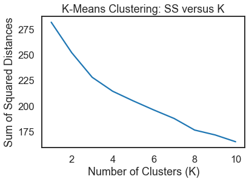

```python
plt.plot(range(1,11),ss)
plt.xlabel('Number of Clusters (K)')
plt.ylabel('Sum of Squared Distances')
plt.title('K-Means Clustering: SS versus K')
plt.show()
```

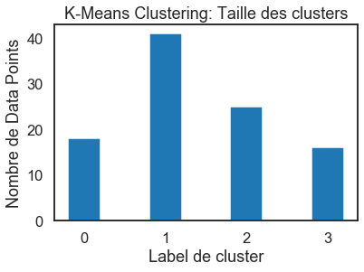

```python
kmeans = KMeans(n_clusters=4, random_state=0).fit(x_cols)
customers['cluster'] = kmeans.predict(x_cols)


unique, counts = np.unique(kmeans.labels_, return_counts=True)
plt.bar(unique, counts, align = 'center', width=0.4)
plt.xticks([0,1,2,3])
plt.xlabel('Label de cluster')
plt.ylabel('Nombre de Data Points')
plt.title('K-Means Clustering: Taille des clusters')
plt.show()
```

**Réponse:** La somme des carrés des distances semble diminuer à un taux constant à mesure que le nombre de clusters augmente. Il devient difficile de déterminer le point de "coude", où le taux de changement ralentit.

### Choisir K : la méthode de la silhouette

Il existe une autre méthode qui mesure la façon dont chaque point de données $x_i$ "s'adapte" au cluster qui lui a été attribué *et aussi* la façon dont il s'adapte mal aux autres clusters. C'est une façon différente de considérer le même objectif. Indiquez $a_{x_i}$ comme étant la distance *moyenne* entre $x_i$ et tous les autres points de sa propre cluster $k$. Plus la valeur est faible, mieux c'est. D'autre part, $b_{x_i}$ est la distance moyenne minimale de $x_i$ aux points d'une autre cluster, minimisée sur l'ensemble des clusters. C'est-à-dire qu'il faut calculer séparément pour chaque cluster la distance moyenne de $x_i$ aux points de cette clusters, puis prendre le minimum. La silhouette $s(x_i)$ est définie comme

$$s(x_i) = \frac{b_{x_i} - a_{x_i}}{\max{\left( a_{x_i}, b_{x_i}\right)}}$$

Le score de la silhouette est calculé sur *chaque point de données dans chaque cluster*. Le score de silhouette varie de -1 (un mauvais regroupement) à +1 (un regroupement très dense), 0 indiquant la situation où les regroupements se chevauchent. Certains critères pour le coefficient de silhouette sont fournis dans le tableau ci-dessous.

[output not shown]

Heureusement, scikit-learn fournit une fonction pour calculer cela pour nous (ouf !) appelée [`sklearn.metrics.silhouette_score`](http://scikit-learn.org/stable/modules/generated/sklearn.metrics.silhouette_score.html). Regardez [this article](http://scikit-learn.org/stable/auto_examples/cluster/plot_kmeans_silhouette_analysis.html) sur le choix de $K$ dans scikit-learn, car cela vous aidera dans la prochaine série d'exercices.

### Exercice

**Exercice:** En utilisant la documentation de la fonction `silhouette_score` ci-dessus, construire une série de tracés de silhouettes comme ceux de l'article lié ci-dessus.

**Exercice:** Calculer le score moyen de la silhouette pour chaque $K$ et le tracer. Quels $K$ le tracé suggère-t-il de choisir ? Est-ce différent de ce que nous avons trouvé en utilisant la méthode du coude ?

**Le score de coefficient de silouette** mesure le degré de définition des clusters. Un clusters bien définie aura une petite distance moyenne à l'intérieur de chaque cluster et une grande distance moyenne avec le cluster suivant le plus proche.

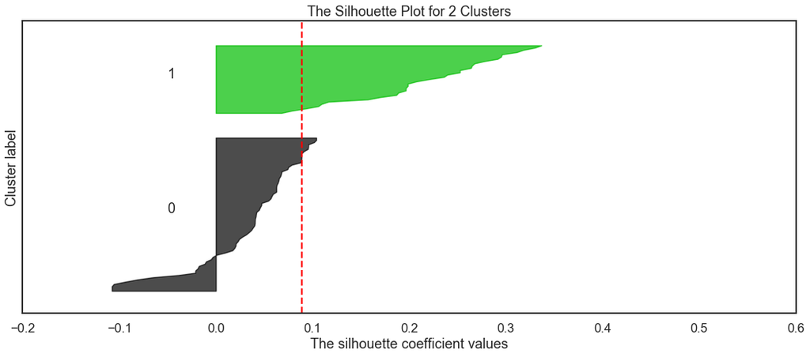

```
pour n_clusters = 2, le score silouette moyen est : 0.08911656187360473
```

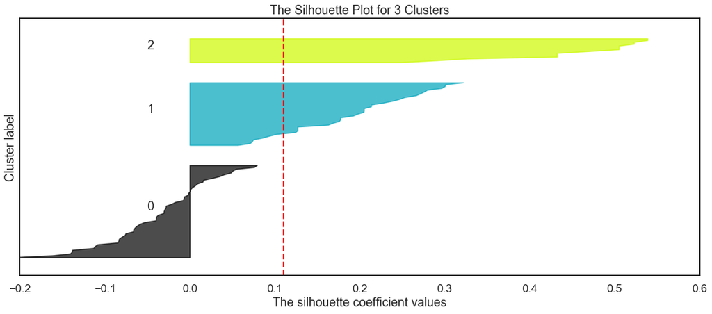

```
pour n_clusters = 3, le score silouette moyen est : 0.11015391298263667
```

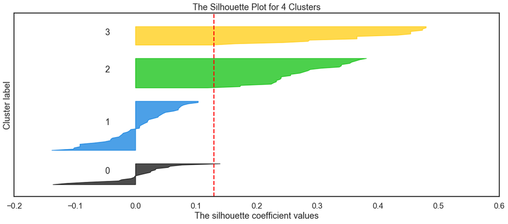

```
pour n_clusters = 4, le score silouette moyen est : 0.12941883590155936
```

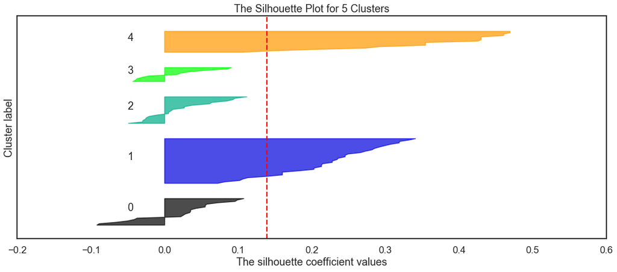

```
pour n_clusters = 5, le score silouette moyen est : 0.13911006290392372
```

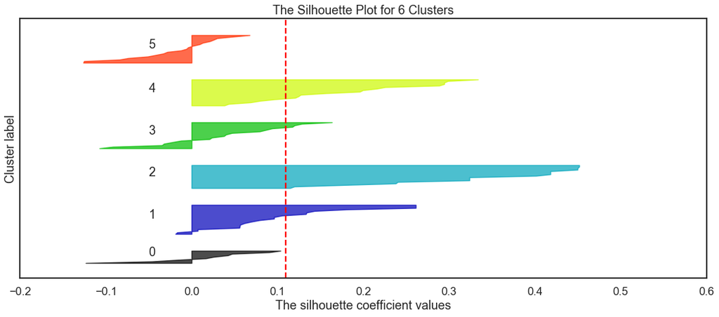

```
pour n_clusters = 6, le score silouette moyen est : 0.10979895247757922
```

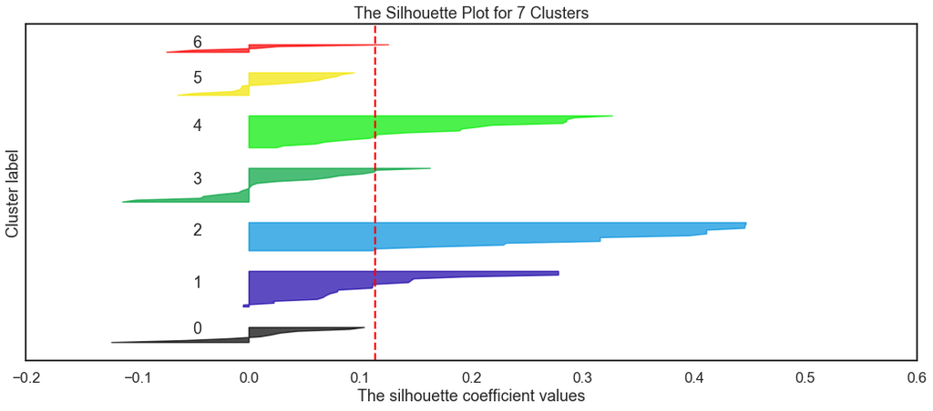

```
pour n_clusters = 7, le score silouette moyen est : 0.11326943929616652
```

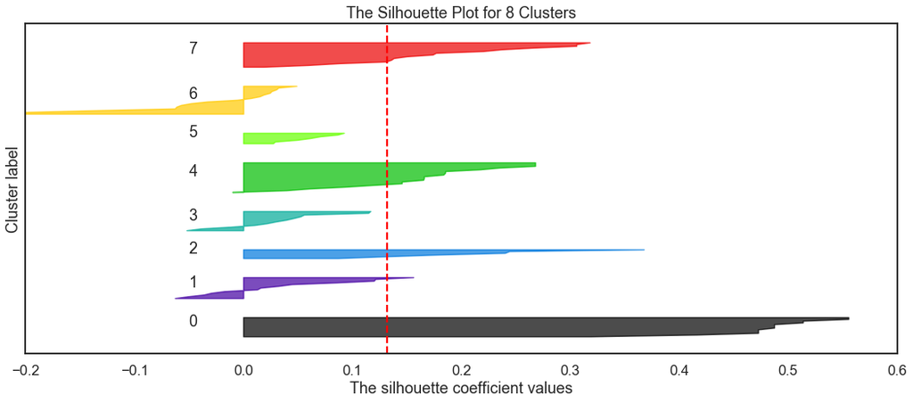

```
pour n_clusters = 8, le score silouette moyen est : 0.13198496281110994
```

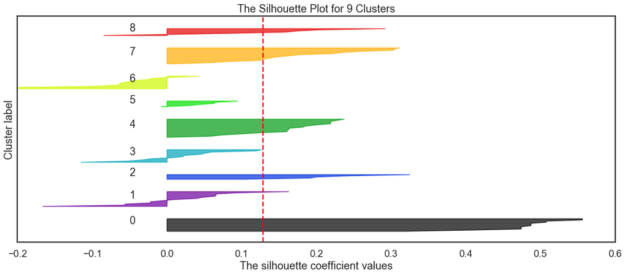

```
pour n_clusters = 9, le score silouette moyen est : 0.1291115731137975
```

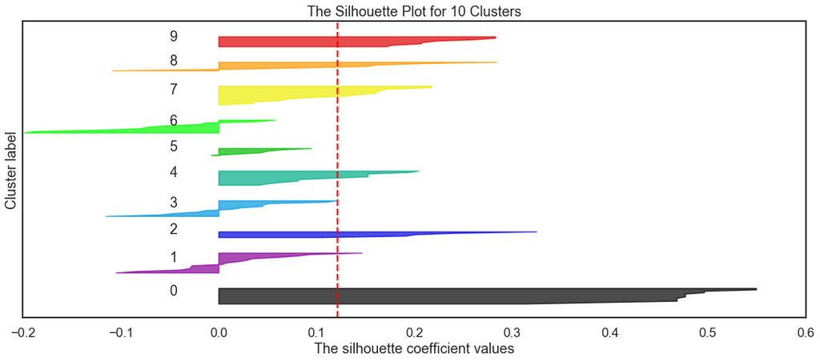

```
pour n_clusters = 10, le score silouette moyen est : 0.1216086963107709
```

```python
from sklearn import metrics
import matplotlib.cm as cm

silhouette = []
for k in range(2,11):

    # Estimer le regroupement de K-means et calculer les scores de silhouette
    kmeans = KMeans(n_clusters=k, random_state=0)
    cluster_labels = kmeans.fit_predict(x_cols)
    silhouette_score = metrics.silhouette_score(x_cols, cluster_labels, metric='euclidean')
    sample_silhouette_values = metrics.silhouette_samples(x_cols, cluster_labels)
    silhouette.append(silhouette_score)

    fig, ax = plt.subplots(1,1)
    fig.set_size_inches(18,7)

    # tracé de la Silhouette
    ax.set_xlim([-0.2, 0.6])
    ax.set_ylim([0, len(customers) + (k + 1) * 10])

    y_lower = 10
    for i in range(k):
        cluster_i = sample_silhouette_values[cluster_labels == i]
        size_cluster_i = len(cluster_i)
        cluster_i.sort()

        y_upper = y_lower + size_cluster_i

        color = cm.nipy_spectral(float(i)/k)
        ax.fill_betweenx(np.arange(y_lower,y_upper), 0, cluster_i, facecolor=color, edgecolor=color, alpha=0.7)

        ax.text(-0.05, y_lower+0.5*size_cluster_i, str(i))

        y_lower = y_upper + 10

    ax.set_title("The Silhouette Plot for {} Clusters".format(k))
    ax.set_xlabel("The silhouette coefficient values")
    ax.set_ylabel("Cluster label")

    # The vertical line for average silhouette score of all the values
    ax.axvline(x=silhouette_score, color="red", linestyle="--")

    ax.set_yticks([])  # Clear the yaxis labels / ticks
    ax.set_xticks([-0.2, -0.1, 0, 0.1, 0.2, 0.3, 0.4, 0.5, 0.6])

    plt.show()
    print('pour n_clusters = {}, le score silouette moyen est : {}'.format(k, silhouette_score))
```

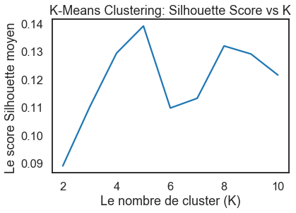

```python
# Plot Silhouette Scores against K number of clusters
plt.plot(range(2,11), silhouette)
plt.xlabel('Le nombre de cluster (K)')
plt.ylabel('Le score Silhouette moyen ')
plt.title('K-Means Clustering: Silhouette Score vs K')
plt.show()
```

### Choisir $K$ : La statistique de Gap

Il y a une dernière méthode qui vaut la peine d'être couverte pour le choix de $K$,dite la statistique de Gap. Le calcul de la statistique de l'écart s'appuie sur la somme des carrés établie dans la discussion sur la méthode du coude, et la compare à la somme des carrés d'une "distribution nulle", c'est-à-dire un ensemble aléatoire de points sans regroupement. L'estimation du nombre optimal de clusters $K$ est la valeur pour laquelle $\log{SS}$ se situe le plus loin sous celle de la distribution de référence :

$$G_k = E_n^*\{\log SS_k\} - \log SS_k$$

En d'autres termes, un bon regroupement produit une différence beaucoup plus importante entre la distribution de référence et les données regroupées. La distribution de référence est une procédure de Monte Carlo (randomisation) qui construit des distributions aléatoires de points $B$ dans le cadre (limites) des données originales et applique ensuite des moyennes K à cette distribution synthétique de points de données... $E_n^*\{\log SS_k\}$ est juste la moyenne $SS_k$ sur toutes les répliques $B$. Nous calculons ensuite l'écart-type $\sigma_{SS}$ des valeurs de $SS_k$ calculées à partir des répliques $B$ de la distribution de référence et calculons

$$s_k = \sqrt{1+1/B}\sigma_{SS}$$

Enfin, nous choisissons $K=k$ de sorte que $G_k \geq G_{k+1} - s_{k+1}$.

### A côté : Choisir $K$ quand on a des étiquettes

L'apprentissage non supervisé suppose que nous n'avons pas les étiquettes. Dans certaines situations, nous pouvons souhaiter regrouper les données qui sont étiquetées. Le calcul du nombre optimal de clusters est beaucoup plus facile si nous avons accès aux étiquettes. Plusieurs méthodes sont disponibles. Nous n'entrerons pas dans les calculs ou les détails puisqu'il est rare d'avoir accès aux labels, mais nous fournissons les noms et les références de ces mesures.

- Indice Rand ajusté
- Information mutuelle
- V-Mesure
- Indice Fowlkes-Mallows

Voir [cet article] (http://scikit-learn.org/stable/modules/clustering.html) pour plus d'informations sur ces mesures.

## Visualisation des clusters à l'aide de l'ACP

Comment visualiser les clusters ? Si nous n'avions que deux caractéristiques, nous pourrions probablement tracer les données telles quelles. Mais nous avons 100 points de données contenant chacun 32 caractéristiques (dimensions). L'analyse en composantes principales (ACP) nous aidera à réduire la dimensionnalité de nos données de 32 à quelque chose de moins. Pour une visualisation sur le plan des coordonnées, nous utiliserons 2 dimensions. Dans cet exercice, nous allons l'utiliser pour transformer notre ensemble de données multidimensionnelles en un ensemble de données bidimensionnelles.

Ce n'est qu'une des utilisations de l'ACP pour la réduction des dimensions. Nous pouvons également utiliser l'ACP lorsque nous voulons effectuer une régression mais que nous disposons d'un ensemble de variables fortement corrélées. L'ACP permet de décomposer ces corrélations en un plus petit nombre de caractéristiques/prédicteurs qui sont tous orthogonaux (non corrélés). L'ACP est également utilisée pour réduire un grand ensemble de variables en un ensemble beaucoup plus petit.

### Ensemble d'exercices de contrôle IV

**Exercice:** Utilisez l'ACP pour tracer vos clusters:

- Utilisez la fonction [`PCA`] (http://scikit-learn.org/stable/modules/generated/sklearn.decomposition.PCA.html) de Scikit-learn pour réduire la dimensionnalité de vos données de clustering à 2 composantes
- Créez un cadre de données avec les champs suivants :
  - nom du client
  - ID du cluster à laquelle le client appartient
  - les deux composantes de l'ACP (les étiqueter "x" et "y")
- Tracez un nuage de points des colonnes "x" et "y
- Points de code de couleur différents selon l'ID de la cluster
- A quoi ressemblent les clusters ?
- D'après ce que vous voyez, quel est le meilleur rapport qualité-prix pour $K$ ? De plus, quelle méthode de choix des $K$ semble avoir produit le résultat optimal visuellement ?

**Exercice:** Maintenant, regardez à la fois les données brutes originales sur les offres et les transactions et regardez les clusters ajustés. Racontez une histoire sur les clusters dans le contexte des données originales. Par exemple, les groupes correspondent-ils à des variantes de vin ou à quelque chose d'autre d'intéressant ?

```python
# Apply PCA to reduce 32 dimensions into 2 components
from sklearn.decomposition import PCA
pca = PCA(n_components=2, random_state=0)
customers['x'] = pca.fit_transform(x_cols)[:,0]
customers['y'] = pca.fit_transform(x_cols)[:,1]
```

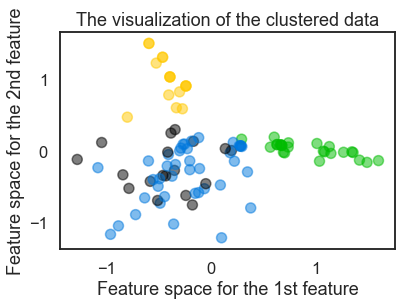

```python
# Create a scatter plot of the two principal components
colors = cm.nipy_spectral(customers.cluster.astype(float) / 4)
plt.scatter(customers.x, customers.y, marker='o', s=100, alpha=0.5, c=colors)
plt.title("The visualization of the clustered data")
plt.xlabel("Feature space for the 1st feature")
plt.ylabel("Feature space for the 2nd feature")
plt.show()
```

```python
# Group transactions data by clusters to see the frequency of purchase for each offer
df_clusters = customers.groupby('cluster').mean()
df_clusters = df_clusters.stack().unstack('cluster').reset_index()
```

```python
# Merge clustered data with offer details and show cluster's tendency to purchase each offer
df = pd.merge(df_clusters, df_offers, how='left', on='offer_id')
```

```python
df[df[0]>0.33]
```

|  | offer_id | 0 | 1 | 2 | 3 | campaign | varietal | min_qty | discount | origin | past_peak |
| --- | --- | --- | --- | --- | --- | --- | --- | --- | --- | --- | --- |
| 0 | 1 | 0.444444 | 0.024390 | 0.00 | 0.0625 | January | Malbec | 72.0 | 56.0 | France | False |
| 10 | 11 | 0.555556 | 0.073171 | 0.00 | 0.0000 | May | Champagne | 72.0 | 85.0 | France | False |
| 21 | 22 | 0.500000 | 0.292683 | 0.00 | 0.0000 | August | Champagne | 72.0 | 63.0 | France | False |
| 24 | 25 | 0.333333 | 0.000000 | 0.00 | 0.0000 | October | Cabernet Sauvignon | 72.0 | 59.0 | Oregon | True |
| 29 | 30 | 0.333333 | 0.000000 | 0.64 | 0.0000 | December | Malbec | 6.0 | 54.0 | France | False |

```python
df[df[1]>0.33]
```

|  | offer_id | 0 | 1 | 2 | 3 | campaign | varietal | min_qty | discount | origin | past_peak |
| --- | --- | --- | --- | --- | --- | --- | --- | --- | --- | --- | --- |
| 30 | 31 | 0.166667 | 0.341463 | 0.0 | 0.0 | December | Champagne | 72.0 | 89.0 | France | False |

```python
df[df[2]>0.33]
```

|  | offer_id | 0 | 1 | 2 | 3 | campaign | varietal | min_qty | discount | origin | past_peak |
| --- | --- | --- | --- | --- | --- | --- | --- | --- | --- | --- | --- |
| 6 | 7 | 0.000000 | 0.170732 | 0.480000 | 0.000000 | March | Prosecco | 6.0 | 40.0 | Australia | True |
| 7 | 8 | 0.000000 | 0.219512 | 0.440000 | 0.000000 | March | Espumante | 6.0 | 45.0 | South Africa | False |
| 17 | 18 | 0.000000 | 0.073171 | 0.440000 | 0.000000 | July | Espumante | 6.0 | 50.0 | Oregon | False |
| 28 | 29 | 0.000000 | 0.024390 | 0.640000 | 0.000000 | November | Pinot Grigio | 6.0 | 87.0 | France | False |
| 29 | 30 | 0.333333 | 0.000000 | 0.640000 | 0.000000 | December | Malbec | 6.0 | 54.0 | France | False |
| 32 | x | -0.428499 | -0.214372 | 0.925277 | -0.414356 | NaN | NaN | NaN | NaN | NaN | NaN |

```python
df[df[3]>0.33]
```

|  | offer_id | 0 | 1 | 2 | 3 | campaign | varietal | min_qty | discount | origin | past_peak |
| --- | --- | --- | --- | --- | --- | --- | --- | --- | --- | --- | --- |
| 1 | 2 | 0.222222 | 0.000000 | 0.000000 | 0.37500 | January | Pinot Noir | 72.0 | 17.0 | France | False |
| 16 | 17 | 0.000000 | 0.000000 | 0.000000 | 0.43750 | July | Pinot Noir | 12.0 | 47.0 | Germany | False |
| 23 | 24 | 0.000000 | 0.000000 | 0.000000 | 0.75000 | September | Pinot Noir | 6.0 | 34.0 | Italy | False |
| 25 | 26 | 0.111111 | 0.024390 | 0.000000 | 0.75000 | October | Pinot Noir | 144.0 | 83.0 | Australia | False |
| 33 | y | -0.221446 | -0.309047 | 0.025677 | 1.00094 | NaN | NaN | NaN | NaN | NaN | NaN |

### Exercise Set V

As we saw earlier, PCA has a lot of other uses. Since we wanted to visualize our data in 2 dimensions, restricted the number of dimensions to 2 in PCA. But what is the true optimal number of dimensions?

**Exercise:** Using a new PCA object shown in the next cell, plot the `explained_variance_` field and look for the elbow point, the point where the curve's rate of descent seems to slow sharply. This value is one possible value for the optimal number of dimensions. What is it?

```python
# Initialize a new PCA model with a default number of components.
import sklearn.decomposition
pca = sklearn.decomposition.PCA()
pca.fit(x_cols)
```

```
PCA(copy=True, iterated_power='auto', n_components=None, random_state=None,
    svd_solver='auto', tol=0.0, whiten=False)
```

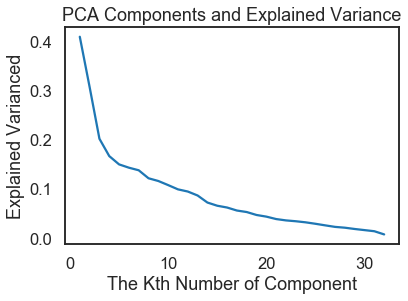

```python
# Plot the explained variance by each component
plt.plot(range(1,33), pca.explained_variance_)
plt.xlabel('The Kth Number of Component')
plt.ylabel('Explained Varianced')
plt.title('PCA Components and Explained Variance')
plt.show()
```

**Résultat:** Ce graphique montre que la quantité de variance expliquée par une composante diminue pour chaque composante successive et que le taux de descente ralentit fortement après la troisième ou quatrième composante. Ainsi, fixer le nombre de composantes à trois ou quatre semble être un bon choix.